# C12 Computing Notes

# Preprocessing

- see script in APM package. Note that small error using lubridate::day() - with version 1.3.3 day() defaults to mday(), where authors intended the result from yday()

# Modelling

- Lets start by having a look around. My challenge is to reproduce the above munging (use dplyr as plyr sooooo slow!)- looks like good practice

```r
# two character vectors for specifying either group:
length(fullSet)
```

```
## [1] 1073
```

```r
head(fullSet)
```

```
## [1] "NumCI"  "NumDR"  "NumECI" "NumEA"  "NumHV"  "NumPS"
```

```r
length(reducedSet)
```

```
## [1] 252
```

```r
head(reducedSet)
```

```
## [1] "NumCI"  "NumDR"  "NumECI" "NumPS"  "NumSCI" "NumSR"
```

### Diagnosing extereme colliniearity

- The trim.matrix() function in subselect takes a square symmetric matrix (in our case the covariance matrix) an eliminates linear combinations

```r
reducedCovMat <- cov(training[, reducedSet])
trimmingResults <- trim.matrix(reducedCovMat)
names(trimmingResults)
```

```
## [1] "trimmedmat"        "numbers.discarded" "names.discarded"
## [4] "size"
```

```r
trimmingResults$names.discarded
```

```
## character(0)
```

- however, when display the same function to the full set, several predictors are identified:

```r
fullCovMat <- cov(training[, fullSet])
fullSetResults <- trim.matrix(fullCovMat)
fullSetResults$names.discarded
```

```
## [1] "NumHV"        "NumPS"        "PS.Dept1033"  "CI.Dept1798"
## [5] "PS.Faculty31" "AstarTotal"   "numPeople"    "Apr"
## [9] "Fri"
```

- caret::findLinearCombos() follows a similar methodology but does not require a square matrix

## Training Models

```r
ctrl <- trainControl(method = "LGOGV",
                     summaryFunction = twoClassSummary,
                     classProbs = TRUE,
                     index = list(TrainSet = pre2008),
                     savePredictions = TRUE)
set.seed(476)
```

### Logistic Regression

- The glm function in base R is commonly used to fit logistic regression models

```r
levels(training$Class)
```

```
## [1] "successful"   "unsuccessful"
```

```r
# simple example
modelFit <- glm(Class ~ Day,
                data = training[pre2008, ],
                # family relates to the distribution of data
                # is binomial for logistic regression
                family = binomial)

modelFit
```

```
##
## Call:  glm(formula = Class ~ Day, family = binomial, data = training[pre2008,
##     ])
##
## Coefficients:
## (Intercept)          Day
##   -0.919335     0.004238
##
## Degrees of Freedom: 6632 Total (i.e. Null);  6631 Residual
## Null Deviance:       9191
## Residual Deviance: 8919  AIC: 8923
```

- The glm function treats the second factor level as the event of interest. Since the slope is positive for day of year it indicates an increase in the rate of unsuccessful grants. To get the probability of a succesful grant, we subtract from one:

```r
successProb <- 1 - predict(modelFit,
                           # predict for several days
                           newdata = data.frame(Day = c(10, 150, 300, 350)),
                           # glm does not predict the class, but can produce
                           # probability of the event
                           type = "response")

successProb
```

```
##         1         2         3         4
## 0.7061907 0.5704337 0.4128749 0.3626229
```

- To add non linear terms, can augment formula:

```r
daySquaredModel <- glm(Class ~ Day + I(Day^2),
                       data = training[pre2008, ],
                       family = binomial)

daySquaredModel
```

```
##
## Call:  glm(formula = Class ~ Day + I(Day^2), family = binomial, data = training[pre2008,
##     ])
##
## Coefficients:
## (Intercept)          Day     I(Day^2)
##   -1.881341     0.018622    -0.000038
##
## Degrees of Freedom: 6632 Total (i.e. Null);  6630 Residual
## Null Deviance:       9191
## Residual Deviance: 8721  AIC: 8727
```

- Annoyingly, the glm() function does not have a non-formula method, so creating models with a large number of predictors takes a little work. Alternative methods will be shown shortly.
- The function rms::lrm() is very similar to glm, and includes helper functions. for example, a restricted cubic spline is a tool for fitting flexible nonlinear functions of a predictor. For day of the year:

```r
rcsFit <- lrm(Class ~ rcs(Day),
              data = training[pre2008, ])
rcsFit
```

```
##
## Logistic Regression Model
##
## lrm(formula = Class ~ rcs(Day), data = training[pre2008, ])
##
##                        Model Likelihood     Discrimination    Rank Discrim.
##                           Ratio Test            Indexes          Indexes
## Obs           6633    LR chi2     461.53    R2       0.090    C       0.614
##  successful   3233    d.f.             4    g        0.538    Dxy     0.229
##  unsuccessful 3400    Pr(> chi2) <0.0001    gr       1.713    gamma   0.242
## max |deriv|  2e-06                          gp       0.122    tau-a   0.114
##                                             Brier    0.234
##
##           Coef    S.E.   Wald Z Pr(>|Z|)
## Intercept -1.6833 0.1110 -15.16 <0.0001
## Day        0.0124 0.0013   9.24 <0.0001
## Day'      -0.0072 0.0023  -3.17 0.0015
## Day''      0.0193 0.0367   0.52 0.6001
## Day'''    -0.0888 0.1026  -0.87 0.3866
```

- By looking at p-values for first few terms, can decide if a non-linear relationship between class and day should be used. Can use rms::Predict() to quickly create a prediction profile accross one or more variabls:

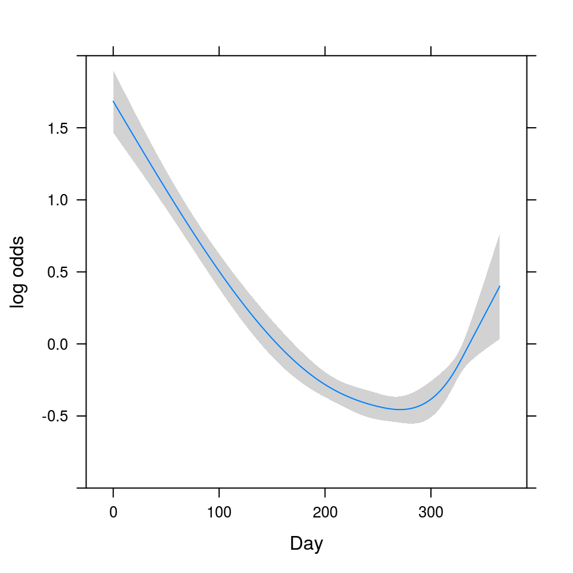

```r
dayProfile <- Predict(rcsFit,
                      # Specify the range of the plot variable
                      Day = 0:365,
                      # Flip the prediction to get the model for
                      # successful grants
                      fun = function(x) -x)
plot(dayProfile, ylab = "log odds")
```

- The plot shoes the log odds - fun argumnet has changed to p of success. It is apparaent that a quadratic term would benefit the model- it would approximate well the trends in the spline
- The train function can be applied for glm to efficiently train and validate models.
- Prior to fitting, add day squared term

```r
training$Day2 <- training$Day^2
testing$Day2 <- testing$Day^2
fullSet <- c(fullSet, "Day2")
reducedSet <- c(reducedSet, "Day2")
```

```r
set.seed(476)
lrFull <- train(training[, fullSet],
                y = training$Class,
                method = "glm",
                metric = "ROC",
                trControl = ctrl)

# get very poor perfomance, algorithm does not converge
# consider filtered below
```

- note at top of output reflect 8190 grants, but summary of sample size lists 6633. The latter reflects the single set of pre-2008 samples. The resampling results is actually the performance of the 2008- holdout set

```r
# for reduced set
lrReduced <- train(training[, reducedSet],
                y = training$Class,
                method = "glm",
                metric = "ROC",
                trControl = ctrl)
lrReduced
```

```
## Generalized Linear Model
##
## 8190 samples
##  253 predictors
##    2 classes: 'successful', 'unsuccessful'
##
## No pre-processing
## Resampling:
##
## Summary of sample sizes: 6633
##
## Resampling results
##
##   ROC        Sens       Spec
##   0.8715406  0.8035088  0.8216819
##
##
```

- the removal of near zero variance precitors yeilds a fairly good fit. The predictions on the holdout sets are held in sub object pred

```r
# not the .parameter column. When train saves predictions, it does so for every tuning parameter.
# This column labels which model generated the predictions. Here, no tuning params, hence 'none'
head(lrReduced$pred)
```

```
##         pred          obs successful unsuccessful rowIndex parameter
## 1 successful   successful  0.9987762  0.001223821     6634      none
## 2 successful   successful  0.8515076  0.148492399     6635      none
## 3 successful   successful  0.9201932  0.079806850     6636      none
## 4 successful   successful  0.9669428  0.033057191     6637      none
## 5 successful unsuccessful  0.6072577  0.392742264     6638      none
## 6 successful   successful  0.9892840  0.010715961     6639      none
##   Resample
## 1 TrainSet
## 2 TrainSet
## 3 TrainSet
## 4 TrainSet
## 5 TrainSet
## 6 TrainSet
```

```r
# and can make a confusion matrix
confusionMatrix(data = lrReduced$pred$pred,
                reference = lrReduced$pred$obs)
```

```
## Confusion Matrix and Statistics
##
##               Reference
## Prediction     successful unsuccessful
##   successful          458          176
##   unsuccessful        112          811
##
##                Accuracy : 0.815
##                  95% CI : (0.7948, 0.834)
##     No Information Rate : 0.6339
##     P-Value [Acc > NIR] : < 2.2e-16
##
##                   Kappa : 0.6107
##  Mcnemar's Test P-Value : 0.0002054
##
##             Sensitivity : 0.8035
##             Specificity : 0.8217
##          Pos Pred Value : 0.7224
##          Neg Pred Value : 0.8787
##              Prevalence : 0.3661
##          Detection Rate : 0.2942
##    Detection Prevalence : 0.4072
##       Balanced Accuracy : 0.8126
##
##        'Positive' Class : successful
##
```

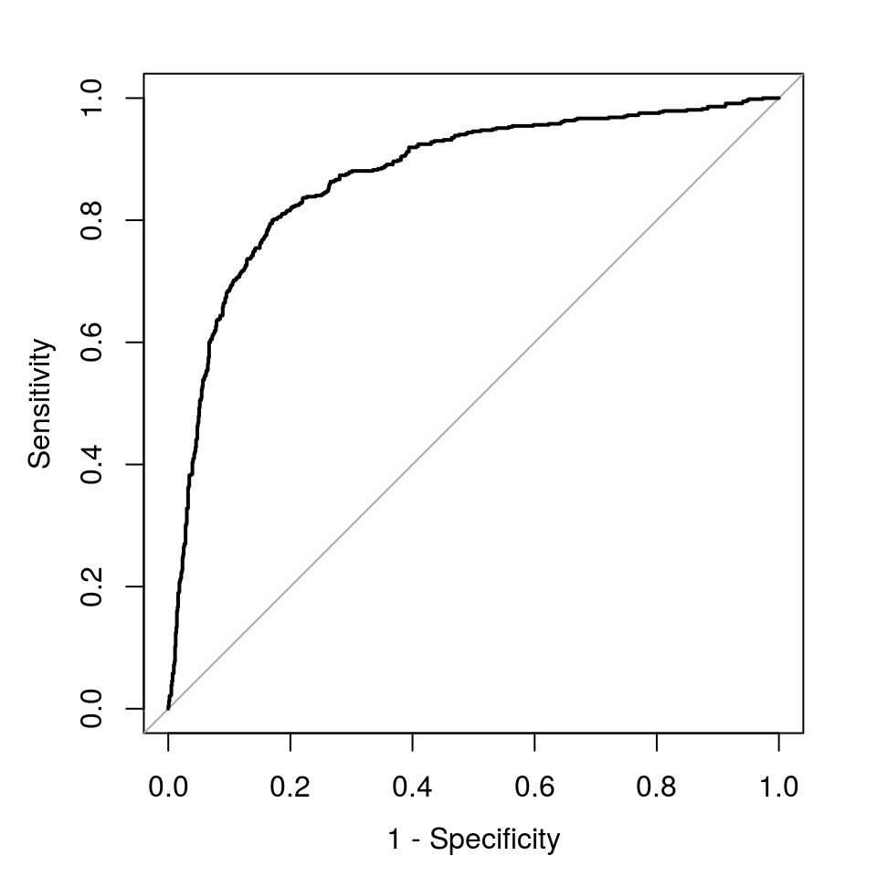

```
##
## Call:
## roc.default(response = lrReduced$pred$obs, predictor = lrReduced$pred$successful,     levels = rev(levels(lrReduced$pred$obs)))
##
## Data: lrReduced$pred$successful in 987 controls (lrReduced$pred$obs unsuccessful) < 570 cases (lrReduced$pred$obs successful).
## Area under the curve: 0.8715
```

```r
# ROC and AUC:

reducedRoc <- roc(response = lrReduced$pred$obs,
                  predictor = lrReduced$pred$successful,
                  # this function assumes that the second
                  # class is the event of interest, so we
                  # reverse the labels
                  levels = rev(levels(lrReduced$pred$obs)))

# use legacy axes so 1-spec vs sens
plot(reducedRoc, legacy.axes = TRUE)
```

```r
auc(reducedRoc)
```

```
## Area under the curve: 0.8715
```

## Linear Discriminant Analysis

- The MASS::lda is a popular function for LDA models. UInput is either a formula or data frame or matrix of predictirs and a grouping variable a s a factor tha contains the class membership information

```r
# center and scale
grantPreProcess <- preProcess(training[pre2008, reducedSet])
grantPreProcess
```

```
##
## Call:
## preProcess.default(x = training[pre2008, reducedSet])
##
## Created from 6633 samples and 253 variables
## Pre-processing: centered, scaled
```

```r
scaledPre2008 <- predict(grantPreProcess,
                         newdata = training[pre2008, reducedSet])
scaled2008HoldOut <- predict(grantPreProcess,
                             newdata = training[-pre2008, reducedSet])

ldaModel <- lda(x = scaledPre2008,
                 grouping = training$Class[pre2008])
```

- As inly two calsses, only one discriminant vector can be obtained. The discriminant vector is held in ldaModel$scaling

```r
head(ldaModel$scaling)
```

```
##                 LD1
## NumCI   0.130167258
## NumDR   0.001727461
## NumECI  0.121947837
## NumPS   0.004266855
## NumSCI -0.065566316
## NumSR  -0.064220945
```

- This information proveds an interpretation aboutpredictors, reloationships amongst predictoors, and if centering and scaling applied, relative importance values. For predictions:

```r
ldaHoldOutPred <- predict(ldaModel, scaled2008HoldOut)
```

- The predicted class, posterior probability and linear discriminat value are all ocntained in this object, thus enabling creating of a confusion matrix, the distribution of posterior probabilities and the distributin of linear discriminant values.
- As we are in a two class setting, there is no training over number of discriminant values (there is just 1). When there are more than two classes, optimal number of discriminant vectors can be caculated in usual way with train(). MASS::lda() has argument dimen in the predict() method. Can automate training with

```r
set.seed(476)
ldaFit1 <- train(x = training[, reducedSet],
                 y = training$Class,
                 method = "lda",
                 preProc = c("center", "scale"),
                 metric = "ROC",
                 trControl = ctrl)
ldaFit1
```

```
## Linear Discriminant Analysis
##
## 8190 samples
##  253 predictors
##    2 classes: 'successful', 'unsuccessful'
##
## Pre-processing: centered, scaled
## Resampling:
##
## Summary of sample sizes: 6633
##
## Resampling results
##
##   ROC        Sens       Spec
##   0.8891644  0.8035088  0.822695
##
##
```

```r
confusionMatrix(data = ldaFit1$pred$pred,
                reference = ldaFit1$pred$obs)
```

```
## Confusion Matrix and Statistics
##
##               Reference
## Prediction     successful unsuccessful
##   successful          458          175
##   unsuccessful        112          812
##
##                Accuracy : 0.8157
##                  95% CI : (0.7955, 0.8346)
##     No Information Rate : 0.6339
##     P-Value [Acc > NIR] : < 2.2e-16
##
##                   Kappa : 0.6119
##  Mcnemar's Test P-Value : 0.0002525
##
##             Sensitivity : 0.8035
##             Specificity : 0.8227
##          Pos Pred Value : 0.7235
##          Neg Pred Value : 0.8788
##              Prevalence : 0.3661
##          Detection Rate : 0.2942
##    Detection Prevalence : 0.4066
##       Balanced Accuracy : 0.8131
##
##        'Positive' Class : successful
##
```

```r
ldaTestClasses <- predict(ldaFit1,
                          newdata = testing[, reducedSet])
ldaTestProbs <- predict(ldaFit1,
                        newdata = testing[, reducedSet],
                        type = "prob")
```

- When the problem involves more than two classes we desire to optimise over the number of discriminant vectors, use train() with method = “lda2” and tuneLength set to the max number of dimenensions wished to evaluate.

## PLS Discriminant Analysis

- PLSDA can be performed using the plsr function within the pls package by using a categorical matrix which defines the response categories. The caret package conatins a function (plsda) that can create the appropriate dummy variable PLS model for the dat and then post-process the raw model predictions to return class probabilities.
- Syntax siminalr to regression model pls, main difference is that a factor variable used for outcome.

```r
plsdaModel <- plsda(x = training[pre2008, reducedSet],
                    y = training[pre2008, "Class"],
                    # data should be on same scale
                    scale = TRUE,
                    # use bayes method for probs
                    probMethod = "Bayes",
                    # specifiy ncomponents
                    ncomp = 4)

# predict hold-out set
plsPred <- predict(plsdaModel,
                   newdata = training[-pre2008, reducedSet])
head(plsPred)
```

```
## [1] successful successful successful successful successful successful
## Levels: successful unsuccessful
```

```r
plsProbs <- predict(plsdaModel,
                    newdata = training[-pre2008, reducedSet],
                    type = "prob")
```

- As the plsdaModel object inherits from the same functions taht would have resulted from the object coming directly from the plsr function, we can use other functions like loadings() and scoreplot()
- The train function can be used with PLS in the classification setting. I guess we should keep probMethod as Bayes?? (could just check if predections are same)

```r
set.seed(476)
plsFit2 <- train(x = training[, reducedSet],
                 y = training$Class,
                 method = "pls",
                 tuneGrid = expand.grid(ncomp = 1:10),
                 preProc = c("center", "scale"),
                 metric = "ROC",
                 trControl = ctrl,
                 probMethod = "Bayes")

plsFit2
```

```
## Partial Least Squares
##
## 8190 samples
##  253 predictors
##    2 classes: 'successful', 'unsuccessful'
##
## Pre-processing: centered, scaled
## Resampling:
##
## Summary of sample sizes: 6633
##
## Resampling results across tuning parameters:
##
##   ncomp  ROC        Sens       Spec
##    1     0.8361498  0.9122807  0.6160081
##    2     0.8679154  0.8578947  0.7517730
##    3     0.8888222  0.8736842  0.7619048
##    4     0.8949581  0.8596491  0.7771023
##    5     0.8948399  0.8456140  0.7902736
##    6     0.8940374  0.8315789  0.7953394
##    7     0.8901438  0.8228070  0.8064843
##    8     0.8876002  0.8298246  0.8034448
##    9     0.8870003  0.8298246  0.8034448
##   10     0.8838932  0.8210526  0.8074975
##
## ROC was used to select the optimal model using  the largest value.
## The final value used for the model was ncomp = 4.
```

- The basic predict() function evaluates the new samples, and with type=“prob” argument returns class probabilities. Variable importance can be computed thus:

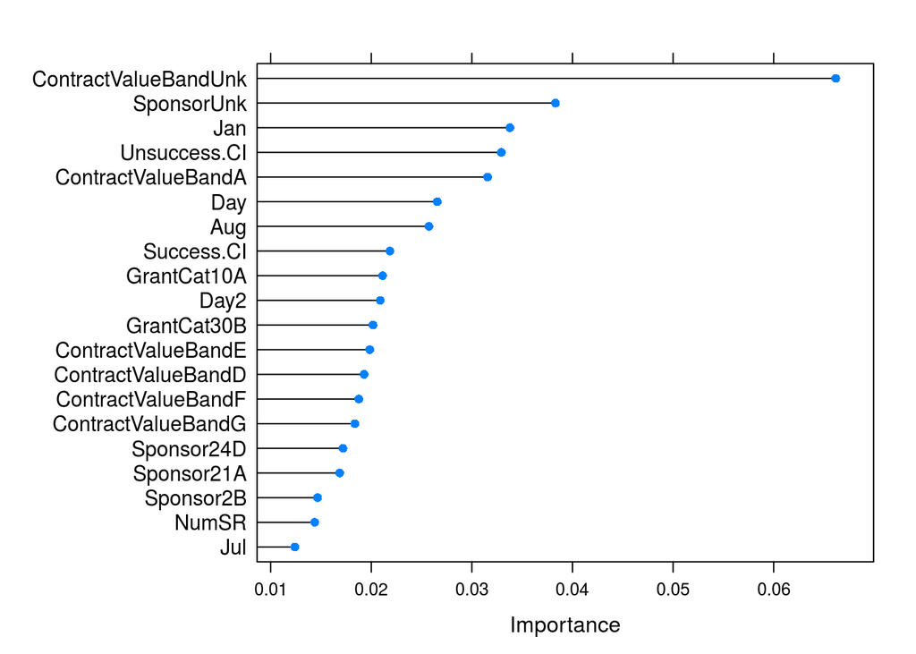

```r
plsImpGrant <- varImp(plsFit2, scale = FALSE)
plot(plsImpGrant, top = 20, scales = list(y = list(cex = 0.95)))
```

## Penalized Models

```r
glmnetModel <- glmnet(x = as.matrix(training[, fullSet]),
                      y = training$Class,
                      family = "binomial")

# predictions for three different levels of regularization
# note the results are strings not factors
predict(glmnetModel,
        newx = as.matrix(training[1:5, fullSet]),
        s = c(0.05, 0.1, 0.2),
        type = "class")
```

```
##   1            2            3
## 1 "successful" "successful" "unsuccessful"
## 2 "successful" "successful" "unsuccessful"
## 3 "successful" "successful" "unsuccessful"
## 4 "successful" "successful" "unsuccessful"
## 5 "successful" "successful" "unsuccessful"
```

```r
# which predictors were used in the model?
predict(glmnetModel,
        newx = as.matrix(training[1:5, fullSet]),
        s = c(0.05, 0.1, 0.2),
        type = "nonzero")
```

```
## $`1`
## [1]   71   72  973 1030 1043 1048 1058
##
## $`2`
## [1] 1030 1043
##
## $`3`
## [1] 1043
```

- As a warning, note that glmnet has a function called auc() (so does pROC). Just be careful which order you load them in. either detach package (eg detach(package:pRoc)) or use namespace convention (eg pROC:::auc) ? I thought it was “::” not “:::”… investigate.
- Can also use train to tune using the area under the ROC curve

```r
glmnGrid <- expand.grid(alpha = c(0, 0.05, 0.1, 0.2, 0.4, 0.6, 0.8, 1),
                        lambda = seq(0.0, 0.2, length = 40))
set.seed(476)
glmnTune <- train(training[, fullSet],
                  y = training$Class,
                  method = "glmnet",
                  tuneGrid = glmnGrid,
                  preProc = c("center", "scale"),
                  metric = "ROC",
                  trControl = ctrl)
```

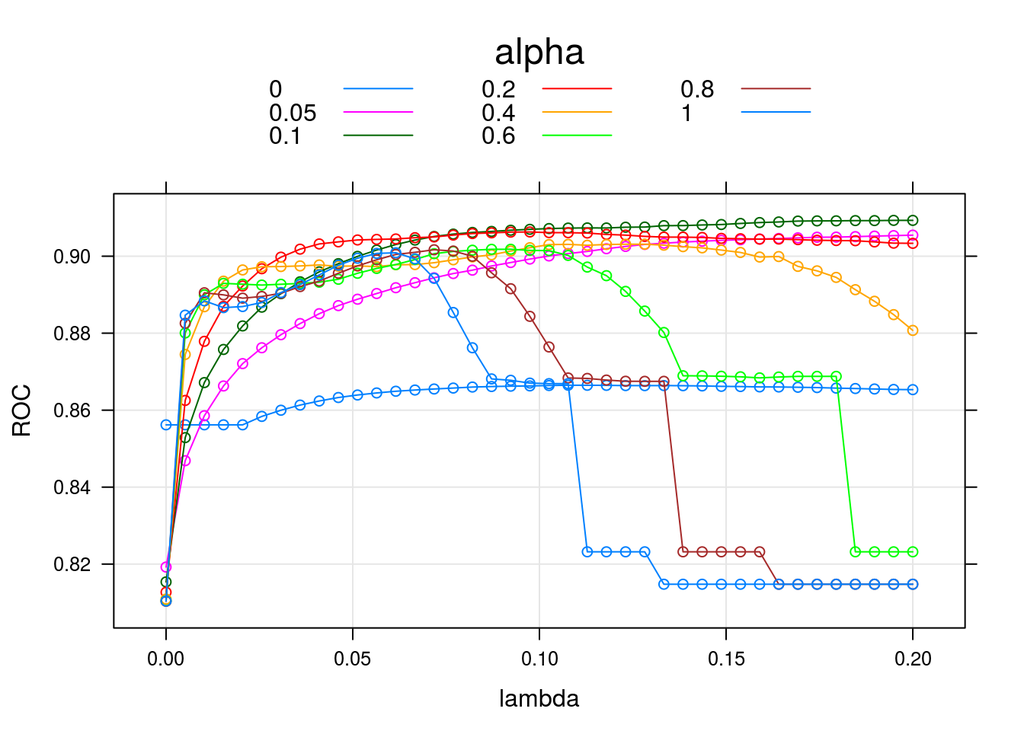

```r
xyplot(ROC ~ lambda,
       data = glmnTune$results,
       groups = alpha,
       type = c("o", "g"),
       auto.key = list(columns = 3,
                       title = "alpha",
                       lines = T,
                       points = F))
```

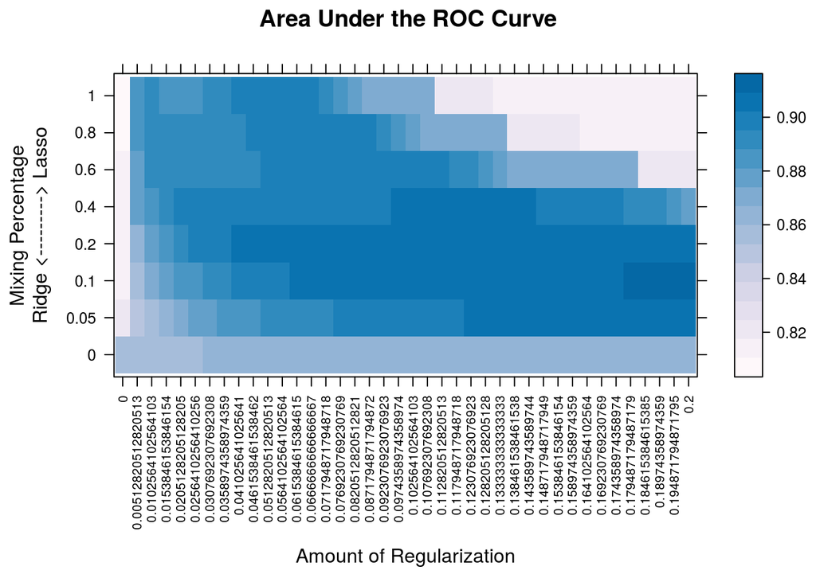

```r
# oh gosh, need to find how to make this non rubbish scale
# might have to pull out stuff and make own heatmap
# rather than custom
trellis.par.set(caretTheme())
glmnPlot <- plot(glmnTune,
                 plotType = "level",
                 cuts = 15,
                 scales = list(x = list(rot = 90, cex = .65)))

update(glmnPlot,
       ylab = "Mixing Percentage\nRidge <---------> Lasso",
       sub = "",
       main = "Area Under the ROC Curve",
       xlab = "Amount of Regularization")
```

## Nearest shrunken Centroids

The initial implementatio is in the pamr package. another package, rda, contains extensions. The implementation in the pamr package is somewhat non standard- needs the predictors to be transposed.

```r
inputData <- list(x = t(training[, fullSet]), y = training$Class)
nscModel <- pamr.train(data = inputData)
```

```
## 123456789101112131415161718192021222324252627282930
```

By default the function cooses 30 appropriate shrinkage values to evaluate. There are options to use specified values for teh shrinkage amount, the prior probabilities and other aspects of the model. pamr.predict() genetrates predictions on new samples as well as determines which specific predictors were usied in the model. For example, to specify a shrinkage value of 5

```r
exampleData <- t(training[1:5, fullSet])
pamr.predict(nscModel, newx = exampleData, threshold = 5)
```

```
## [1] successful   unsuccessful successful   unsuccessful successful
## Levels: successful unsuccessful
```

To determine which predictors were used at the threshold:

```r
thresh17Vars <- pamr.predict(nscModel,
                             newx = exampleData,
                             threshold = 17,
                             type = "nonzero"
                             )
fullSet[thresh17Vars]
```

```
## [1] "Unsuccess.CI"         "SponsorUnk"           "ContractValueBandA"
## [4] "ContractValueBandUnk" "Jan"
```

The package also contains function for K-fold CV to chose an appropiate amouunt of shrinkage, but is restrictd to a single type of resampling and tunes the model with overall accuracy.

Can use train() to give more options for model tuning, as well as a consistent syntax:

```r
nscGrid <- data.frame(threshold = 0:25)
set.seed(476)
nscTuned <- train(x = training[, fullSet],
                  y = training$Class,
                  method = "pam",
                  preProc = c("center", "scale"),
                  tuneGrid = nscGrid,
                  metric = "ROC",
                  trControl = ctrl)
```

```
## 11
```

The predict() function for train does not require the user to manually specifit the shrinkage amount. The predictors() function will list the predcitros used in the prediction equation (at optimum threshold)

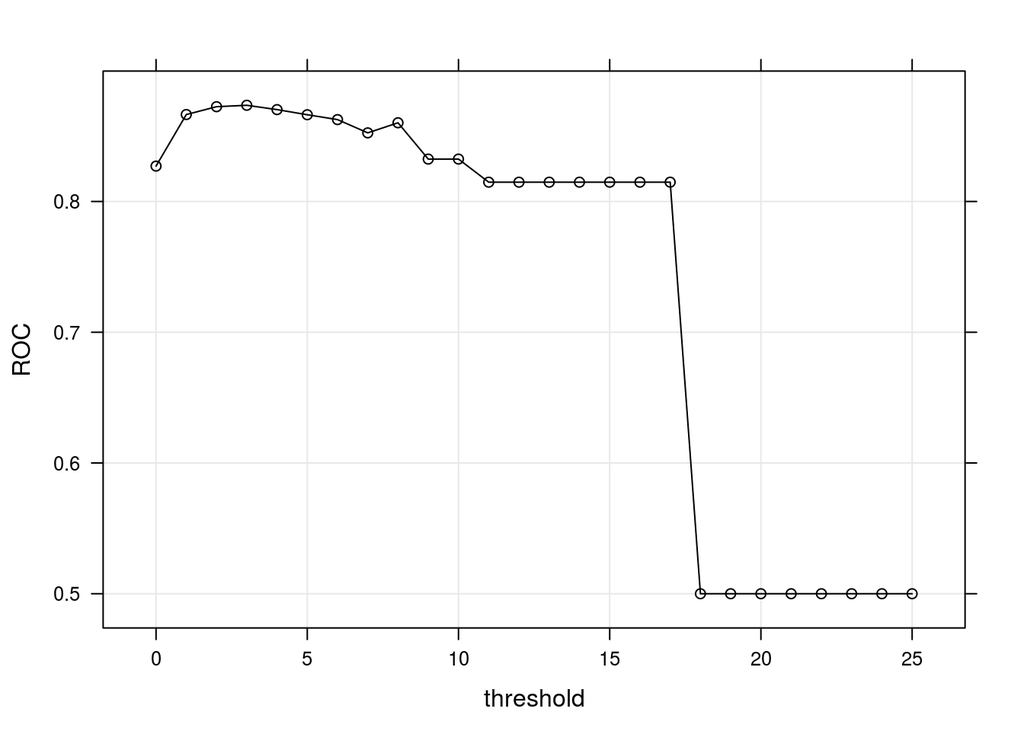

```r
xyplot(ROC ~ threshold,
       data = nscTuned$results,
       type = c("o", "g"))
```

```r
predictors(nscTuned)
```

```
##  [1] "NumSR"                "Success.CI"           "Unsuccess.CI"
##  [4] "Astar.CI"             "AstarTotal"           "Sponsor21A"
##  [7] "Sponsor24D"           "Sponsor2B"            "Sponsor34B"
## [10] "Sponsor6B"            "SponsorUnk"           "ContractValueBandA"
## [13] "ContractValueBandC"   "ContractValueBandD"   "ContractValueBandE"
## [16] "ContractValueBandF"   "ContractValueBandG"   "ContractValueBandUnk"
## [19] "GrantCat10A"          "GrantCat30B"          "Aug"
## [22] "Dec"                  "Jan"                  "Jul"
## [25] "Fri"                  "Sun"                  "Day"
## [28] "Day2"
```

Also, can use varImp to return variable importance based on the distance between the class centroid and overall centroid:

```r
varImp(nscTuned, scale = FALSE)
```

```
## pam variable importance
##
##   only 20 most important variables shown (out of 1074)
##
##                      Importance
## ContractValueBandUnk   -0.22114
## SponsorUnk              0.10122
## Jan                     0.09300
## ContractValueBandA      0.08986
## Unsuccess.CI           -0.07377
## Day                    -0.06415
## Aug                    -0.06201
## Sun                     0.06104
## GrantCat10A            -0.04520
## Success.CI              0.03643
## Day2                   -0.03482
## ContractValueBandE      0.03312
## GrantCat30B            -0.03296
## ContractValueBandD      0.02944
## Sponsor21A              0.02905
## ContractValueBandF      0.02837
## ContractValueBandG      0.02794
## Sponsor24D             -0.02497
## Sponsor2B              -0.01839
## NumSR                   0.01752
```

The positive sign for variable importance implies an increase in event rate, whereas negative implies a decrease in event rate.